# 04 - Fluorinated xenobiotics analysis

## Overview

This notebook analyzes the distribution of fluorine-containing compounds (putative xenobiotics) across food categories, with particular focus on animal products and dairy subcategories.

## Background

Fluorine is rare in natural products but common in synthetic compounds including pharmaceuticals, pesticides, and per- and polyfluoroalkyl substances (PFAS). The presence of fluorinated compounds in food likely indicates xenobiotic contamination from various sources.

## Input data

**`ptfi_data_long.csv`** - PTFI features in long format

- `sample_id`, `sample_foodon_leaf_name`, `metabolite`, `intensity`, `element_id`

**`ptfi_non_np_atoms.csv`** - Non-natural product elemental composition

- `element_id`: Metabolite identifier
- `has_F`: Boolean flag for fluorine-containing compounds
- `formula`: Molecular formula

**`ptfi_metadata.csv`** - Sample metadata with FoodOn hierarchy

- `sample_id`, `foodon_level1_name`, `foodon_level2_name`, `foodon_level3_name`, `foodon_level4_name`

## Outputs

1. Heatmap: Fluorinated compounds across FoodOn Level 1 categories
2. Heatmap: Fluorinated compounds in animal product subcategories (Level 4)
3. Heatmap: Fluorinated compounds in dairy products (sample-level)

```python
import pandas as pd
import numpy as np
import matplotlib.pyplot as plt
import seaborn as sns

# Load data
ptfi_long_df = pd.read_csv("ptfi_data_long.csv")
non_np_elements = pd.read_csv("ptfi_non_np_atoms.csv")
metadata = pd.read_csv("ptfi_metadata.csv")

print(f"Loaded {len(ptfi_long_df)} PTFI features")
```

```
Loaded 9814700 PTFI features
```

## Data preparation

Filter for fluorine-containing compounds and merge with metadata.

```python
# Get list of fluorine-containing metabolites
f_elements = list(non_np_elements[non_np_elements["has_F"] == True]["element_id"])
print(f"Found {len(f_elements)} fluorine-containing compounds")

# Filter PTFI data for fluorinated compounds
f_long = ptfi_long_df[ptfi_long_df["metabolite"].isin(f_elements)].copy()

# Merge with formula information
f_long = f_long.merge(
    non_np_elements[["element_id", "formula"]],
    on="element_id"
)

# Merge with FoodOn metadata
f_long = f_long.merge(
    metadata[["sample_id", "foodon_level1_name", "foodon_level2_name",
              "foodon_level3_name", "foodon_level4_name"]],
    on="sample_id"
)

# Remove multi-component food products
f_long = f_long[f_long["foodon_level1_name"] != "multi-component food product"]

print(f"Filtered dataset: {len(f_long)} entries with fluorinated compounds")
f_long.head()
```

```
Found 126 fluorine-containing compounds
Filtered dataset: 42944 entries with fluorinated compounds
```

|  | sample_id | sample_foodon_leaf_name | metabolite | intensity | element_id | element_name | formula | foodon_level1_name | foodon_level2_name | foodon_level3_name | foodon_level4_name |
| --- | --- | --- | --- | --- | --- | --- | --- | --- | --- | --- | --- |
| 0 | GGB100007 | yellow bell pepper (raw) | MET_RP25-20762 | 0.0 | MET_RP25-20762 | C10F21NaO3S-490 | C10F21NaO3S | plant food product | vegetable food product | plant fruit food product | plant fruit as vegetable food product |
| 1 | GGB100008 | pepper (raw) | MET_RP25-20762 | 0.0 | MET_RP25-20762 | C10F21NaO3S-490 | C10F21NaO3S | plant food product | vegetable food product | plant fruit food product | plant fruit as vegetable food product |
| 2 | GGB100009 | pepper (raw) | MET_RP25-20762 | 0.0 | MET_RP25-20762 | C10F21NaO3S-490 | C10F21NaO3S | plant food product | vegetable food product | plant fruit food product | plant fruit as vegetable food product |
| 3 | GGB100010 | sweet green pepper (raw) | MET_RP25-20762 | 0.0 | MET_RP25-20762 | C10F21NaO3S-490 | C10F21NaO3S | plant food product | vegetable food product | plant fruit food product | plant fruit as vegetable food product |
| 4 | GGB100011 | white onion (raw) | MET_RP25-20762 | 0.0 | MET_RP25-20762 | C10F21NaO3S-490 | C10F21NaO3S | plant food product | plant root food product | plant root vegetable food product | onion food product |

```python
# Create mapping from metabolite ID to formula for labeling
id_to_formula_map = f_long[['element_id', 'formula']].drop_duplicates().set_index('element_id')['formula'].to_dict()
```

## Helper functions

Functions to create heatmap data and visualize clustered heatmaps.

```python
def create_heatmap_df_from_long(
    long_df,
    category_col,
    metabolite_col,
    value_col,
    foodon_filter=None,
    foodon_level_filter=None,
    top_n=10,
    apply_log=False
):
    """
    Create heatmap-ready DataFrame by selecting top N metabolites per category.

    Parameters:
    -----------
    long_df : DataFrame
        Long-format data
    category_col : str
        Column for categories (rows in heatmap)
    metabolite_col : str
        Column for metabolites (columns in heatmap)
    value_col : str
        Column for values to aggregate
    foodon_filter : list or None
        List of FoodOn categories to include
    foodon_level_filter : int or None
        FoodOn level to filter on (1-4)
    top_n : int
        Number of top metabolites to select per category
    apply_log : bool
        Whether to apply log10(x+1) transformation

    Returns:
    --------
    DataFrame: Wide-format heatmap data
    """
    # Filter by FoodOn category if specified
    if foodon_filter and foodon_level_filter:
        foodon_level_name = f"foodon_level{foodon_level_filter}_name"
        long_df = long_df[long_df[foodon_level_name].isin(foodon_filter)]

    # Find top N metabolites per category
    mean_values = long_df.groupby([category_col, metabolite_col])[value_col].mean()
    top_metabolites_per_category = mean_values.groupby(
        level=0, group_keys=False
    ).nlargest(top_n)

    # Get master list of all top metabolites
    master_metabolite_list = top_metabolites_per_category.index.get_level_values(
        metabolite_col
    ).unique()

    print(f"Selected {len(master_metabolite_list)} top metabolites across all categories")

    # Create wide-format heatmap data
    final_plot_df = long_df[long_df[metabolite_col].isin(master_metabolite_list)]
    heatmap_df = pd.pivot_table(
        final_plot_df,
        values=value_col,
        index=category_col,
        columns=metabolite_col,
        aggfunc='mean',
        fill_value=0
    )

    # Remove zero columns
    heatmap_df = heatmap_df.loc[:, (heatmap_df != 0).any(axis=0)]

    # Apply log transformation if requested
    if apply_log:
        heatmap_df = np.log10(heatmap_df + 1)

    return heatmap_df


def plot_clustered_heatmap(
    heatmap_df,
    cbar_label='log₁₀(intensity)',
    width=None,
    height=None,
    cell_size=0.4,
    font_scale=3.5
):
    """
    Create hierarchically clustered heatmap.

    Parameters:
    -----------
    heatmap_df : DataFrame
        Wide-format heatmap data
    cbar_label : str
        Colorbar label
    width : float or None
        Figure width (auto-calculated if None)
    height : float or None
        Figure height (auto-calculated if None)
    cell_size : float
        Size of each cell in inches
    font_scale : float
        Seaborn font scale

    Returns:
    --------
    ClusterGrid: Seaborn clustermap object
    """
    if heatmap_df.empty:
        print("Cannot plot heatmap: DataFrame is empty")
        return None

    # Calculate figure size
    if width is None and height is None:
        width = heatmap_df.shape[1] * cell_size
        height = heatmap_df.shape[0] * cell_size

    # Set maximum size
    max_size = 40
    width = min(width, max_size)
    height = min(height, max_size)

    # Set font scale
    sns.set(font_scale=font_scale)

    # Create clustermap
    g = sns.clustermap(
        heatmap_df,
        figsize=(width, height),
        cmap='viridis',
        annot=False,
        linewidths=0.5,
        cbar_kws={'label': cbar_label},
        cbar_pos=(0.02, 0.5, 0.05, 0.18),
        square=True
    )

    # Formatting
    plt.setp(g.ax_heatmap.get_xticklabels(), rotation=90)
    g.ax_heatmap.set_xlabel('Molecular formula')
    g.ax_heatmap.set_ylabel('')
    g.ax_cbar.set_ylabel(cbar_label)

    return g
```

## Figure 1: Fluorinated compounds across FoodOn Level 1 categories

Top 10 fluorinated compounds by mean intensity for each major food category.

```python
# Create heatmap data
heatmap_df = create_heatmap_df_from_long(
    f_long,
    category_col="foodon_level1_name",
    metabolite_col="metabolite",
    value_col='intensity',
    foodon_filter=["animal food product", "plant food product", "fungus food product", "algal food product"],
    foodon_level_filter=1,
    top_n=10,
    apply_log=True
)

# Rename columns to formulas
heatmap_df = heatmap_df.rename(columns=id_to_formula_map)

print("Heatmap data prepared:")
heatmap_df.head()
```

```
Selected 24 top metabolites across all categories
Heatmap data prepared:
```

| metabolite foodon_level1_name | C10H10F3N3 | C10H10F3N3 | C11H13F13O3Si | C14H17F13 | C18H21FN2O | C19H15FN2O4 | C20H17F2N3O3 | C21H19F2N3O3 | C21H23ClFNO2 | C21H23ClFNO2 | ... | C24H22ClF3O3 | C33H35FN2O5 | C3H2F5I | C4F8I2 | C4F8I2 | C7H3F13O | C8F17KO3S | C8F17KO3S | C8H2F14O2 | C9F21N |
| --- | --- | --- | --- | --- | --- | --- | --- | --- | --- | --- | --- | --- | --- | --- | --- | --- | --- | --- | --- | --- | --- |
| algal food product | 4.247107 | 2.718886 | 0.000000 | 0.000000 | 3.922292 | 0.000000 | 0.000000 | 4.042412 | 4.167336 | 5.113156 | ... | 0.000000 | 2.928177 | 3.605467 | 0.000000 | 0.000000 | 0.000000 | 0.000000 | 0.000000 | 0.00000 | 0.000000 |
| animal food product | 2.314233 | 2.937472 | 0.000000 | 0.000000 | 0.000000 | 0.000000 | 2.518874 | 3.054220 | 2.436033 | 4.230403 | ... | 3.058658 | 4.215562 | 2.809974 | 3.111858 | 3.179405 | 4.322867 | 4.868938 | 2.931392 | 3.34693 | 3.919169 |
| fungus food product | 0.000000 | 4.081852 | 0.000000 | 0.000000 | 0.000000 | 3.966064 | 3.258556 | 3.766089 | 0.000000 | 3.705319 | ... | 2.671559 | 3.871949 | 2.659741 | 0.000000 | 0.000000 | 3.488778 | 0.000000 | 3.505368 | 0.00000 | 0.000000 |
| plant food product | 2.764812 | 2.770288 | 4.136392 | 3.869699 | 0.000000 | 0.000000 | 2.776002 | 3.836196 | 3.065567 | 4.214074 | ... | 2.932045 | 3.708835 | 2.846040 | 0.000000 | 0.000000 | 4.024686 | 0.000000 | 3.151970 | 3.12188 | 0.000000 |

4 rows × 24 columns

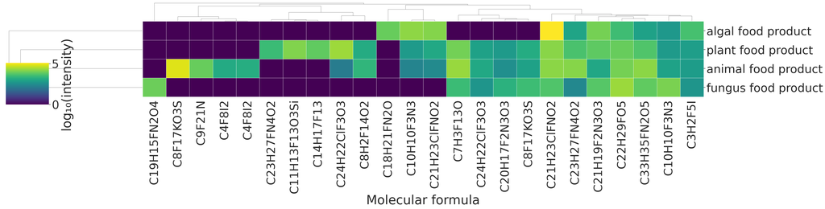

```python
# Plot clustered heatmap
cluster_g = plot_clustered_heatmap(
    heatmap_df,
    cbar_label='log₁₀(intensity)',
    cell_size=2.7,
    font_scale=3.5
)

plt.savefig('results/fluorine_foodon_level1.png', dpi=300, bbox_inches='tight')
plt.show()
```

## Figure 2: Fluorinated compounds in animal products (FoodOn Level 4)

Detailed view of fluorinated compound distribution across specific animal product types.

```python
# Create heatmap for animal products at Level 4
heatmap_df = create_heatmap_df_from_long(
    f_long,
    category_col="foodon_level4_name",
    metabolite_col="metabolite",
    value_col="intensity",
    foodon_filter=["animal food product"],
    foodon_level_filter=1,
    top_n=10,
    apply_log=True
)

# Rename columns to formulas
heatmap_df = heatmap_df.rename(columns=id_to_formula_map)

print("Animal products heatmap data:")
heatmap_df.head()
```

```
Selected 30 top metabolites across all categories
Animal products heatmap data:
```

| metabolite foodon_level4_name | C10F21NaO3S | C10H10F3N3 | C10H10F3N3 | C11F20 | C11H13F13N2O2S | C13H8F16O2 | C19H23FO4 | C20H17F2N3O3 | C20H20F3N3O3 | C21H19F2N3O3 | ... | C33H35FN2O5 | C4F8I2 | C4F8I2 | C7H3F13O | C8F17KO3S | C8F17KO3S | C8H2F14O2 | C9ClF17O | C9F21N | C9H11F5O2 |
| --- | --- | --- | --- | --- | --- | --- | --- | --- | --- | --- | --- | --- | --- | --- | --- | --- | --- | --- | --- | --- | --- |
| avian egg food product | 0.000000 | 0.000000 | 0.00000 | 0.000000 | 2.819766 | 0.0 | 0.000000 | 0.0 | 0.000000 | 0.0 | ... | 3.754300 | 0.000000 | 0.0 | 0.000000 | 0.000000 | 0.0 | 3.408906 | 0.000000 | 0.000000 | 0.0000 |
| bovine dairy food product | 3.971036 | 0.000000 | 0.00000 | 0.000000 | 2.789558 | 0.0 | 0.000000 | 0.0 | 2.443484 | 0.0 | ... | 3.495009 | 0.000000 | 0.0 | 3.980175 | 3.137215 | 0.0 | 3.309071 | 2.480600 | 4.281673 | 0.0000 |
| bovine meat food product | 0.000000 | 0.000000 | 3.40519 | 0.000000 | 2.885826 | 0.0 | 2.072901 | 0.0 | 0.000000 | 0.0 | ... | 4.408333 | 0.000000 | 0.0 | 4.423617 | 0.000000 | 0.0 | 3.173780 | 0.000000 | 0.000000 | 3.9007 |
| cheese food product | 3.178737 | 2.886716 | 0.00000 | 2.595124 | 2.404080 | 0.0 | 2.796630 | 0.0 | 0.000000 | 0.0 | ... | 4.164478 | 3.685643 | 0.0 | 4.635928 | 5.410411 | 0.0 | 3.598536 | 3.518492 | 4.358352 | 0.0000 |
| cichlid food product | 0.000000 | 0.000000 | 0.00000 | 0.000000 | 2.623722 | 0.0 | 0.000000 | 0.0 | 2.702061 | 0.0 | ... | 3.933998 | 0.000000 | 0.0 | 0.000000 | 0.000000 | 0.0 | 0.000000 | 0.000000 | 0.000000 | 0.0000 |

5 rows × 26 columns

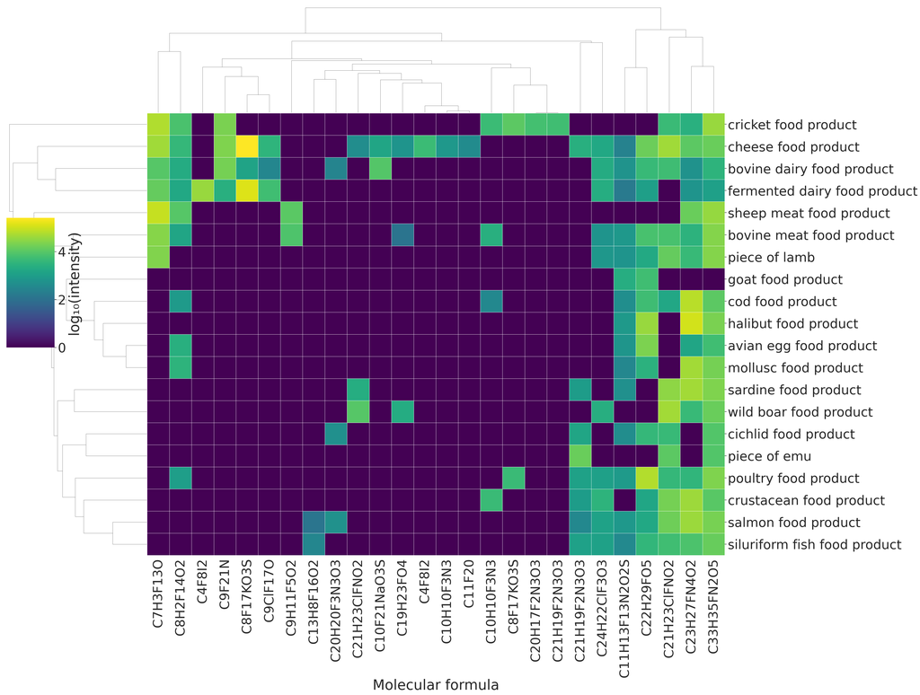

```python
# Plot clustered heatmap
cluster_g = plot_clustered_heatmap(
    heatmap_df,
    width=50,
    height=30,
    cbar_label='log₁₀(intensity)',
    font_scale=3.5
)

plt.savefig('results/fluorine_animal_products.png', dpi=300, bbox_inches='tight')
plt.show()
```

## Figure 3: Fluorinated compounds in dairy products

Sample-level clustering of fluorinated compounds in dairy products reveals distinct patterns between cheese types.

```python
# Create heatmap for dairy products at sample level
heatmap_df = create_heatmap_df_from_long(
    f_long,
    category_col="sample_foodon_leaf_name",
    metabolite_col="metabolite",
    value_col='intensity',
    foodon_filter=["dairy food product"],
    foodon_level_filter=3,
    top_n=10,
    apply_log=True
)

# Rename columns to formulas
heatmap_df = heatmap_df.rename(columns=id_to_formula_map)

print("Dairy products heatmap data:")
heatmap_df.head()
```

```
Selected 30 top metabolites across all categories
Dairy products heatmap data:
```

| metabolite sample_foodon_leaf_name | C10F21NaO3S | C10H10F3N3 | C11F20 | C11H13F13N2O2S | C18H20FN3O4 | C19H23FO4 | C19H23FO4 | C20H20F3N3O3 | C21H19F2N3O3 | C21H23ClFNO2 | ... | C33H35FN2O5 | C3H2F5I | C4F8I2 | C4F8I2 | C7H3F13O | C8F17KO3S | C8H2F14O2 | C8H7F9O2 | C9ClF17O | C9F21N |
| --- | --- | --- | --- | --- | --- | --- | --- | --- | --- | --- | --- | --- | --- | --- | --- | --- | --- | --- | --- | --- | --- |
| Monterey Jack cheese (pasteurized) | 0.000000 | 0.0 | 0.0 | 0.000000 | 0.0 | 0.0 | 4.113350 | 0.0 | 4.260448 | 0.0 | ... | 0.000000 | 4.396493 | 4.447202 | 0.0 | 0.000000 | 5.896091 | 0.000000 | 0.0 | 4.014241 | 4.850748 |
| Monterey Jack cheese flavoured with chili flakes | 0.000000 | 0.0 | 0.0 | 0.000000 | 0.0 | 0.0 | 0.000000 | 0.0 | 4.316388 | 0.0 | ... | 3.613823 | 0.000000 | 0.000000 | 0.0 | 0.000000 | 5.660435 | 0.000000 | 0.0 | 3.828751 | 0.000000 |
| butter (unsalted) | 0.000000 | 0.0 | 0.0 | 3.332834 | 0.0 | 0.0 | 0.000000 | 0.0 | 0.000000 | 0.0 | ... | 0.000000 | 0.000000 | 0.000000 | 0.0 | 0.000000 | 0.000000 | 0.000000 | 0.0 | 0.000000 | 0.000000 |
| cheddar cheese (mild) | 0.000000 | 0.0 | 0.0 | 0.000000 | 0.0 | 0.0 | 3.973982 | 0.0 | 0.000000 | 0.0 | ... | 0.000000 | 0.000000 | 3.893666 | 0.0 | 0.000000 | 0.000000 | 0.000000 | 0.0 | 0.000000 | 0.000000 |
| cheddar cheese (sharp) | 3.132954 | 0.0 | 0.0 | 0.000000 | 0.0 | 0.0 | 0.000000 | 0.0 | 0.000000 | 0.0 | ... | 0.000000 | 0.000000 | 3.868889 | 0.0 | 5.256812 | 5.401567 | 4.249854 | 0.0 | 0.000000 | 0.000000 |

5 rows × 25 columns

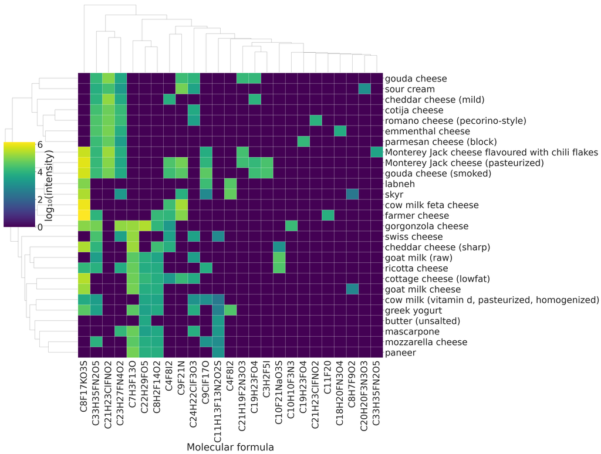

```python
# Plot clustered heatmap
cluster_g = plot_clustered_heatmap(
    heatmap_df,
    width=50,
    height=30,
    cbar_label='log₁₀(intensity)',
    font_scale=3.7
)

plt.savefig('results/fluorine_dairy_products.png', dpi=300, bbox_inches='tight')
plt.show()
```